# Microarreglos

Mayela Fosado

23/3/2022

### **Expresión diferencial y anotación**

# Cargar archivo de la parte anterior **“Microarreglos Affymetrix”** y librerías”

Archivo:

```r
exprs <- read.table("expr_normalizada.txt", header=TRUE, row.names=1)
```

Librerías:

```r
library(Biobase)
library(limma)
```

## Revisar los datos

```r
head(exprs)
```

```
##                    ko1       ko2       ko3       wt1       wt2       wt3
## 1415670_at    9.678634  9.710057  9.594718  9.721163  9.712254  9.687904
## 1415671_at    8.872975  8.865341  8.904089  8.854967  8.946216  8.966084
## 1415672_at   10.354395 10.318061 10.222677 10.469679 10.556538 10.436530
## 1415673_at   10.229100 10.318935  9.899033 10.052814  9.869369  9.974674
## 1415674_a_at 10.392037 10.401660 10.442584 10.352182 10.148918 10.321430
## 1415675_at    9.104457  8.972829  8.889293  8.975043  8.893407  8.997819
```

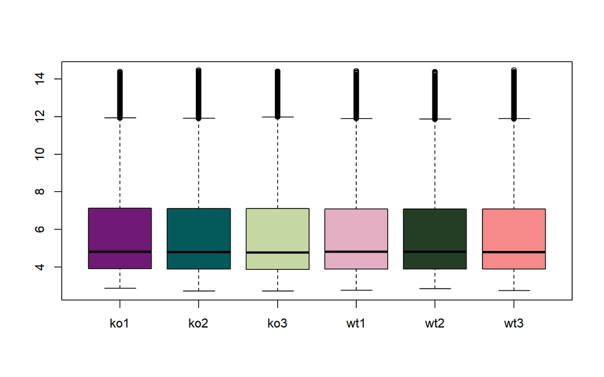

```r
boxplot(exprs, col=c("#711A75", "#05595B", "#C5D8A4", "#E4AEC5", "#243D25", "#F68989"))
```

# Calcular la expresión diferencial

Crear matrices para las muestras del diseño experimental y los contrastes. Diferenciando las muestras KO y WT, guardándolas en un objeto “des”. Otro objeto “contMatrix” que especifidque que se compara KO vs WT.

```r
types <- factor(c("KO", "KO", "KO", "WT", "WT", "WT" ))
types
```

```
## [1] KO KO KO WT WT WT
## Levels: KO WT
```

```r
design <- model.matrix(~ 0+types)

colnames(design) = levels(types)

design
```

```
##   KO WT
## 1  1  0
## 2  1  0
## 3  1  0
## 4  0  1
## 5  0  1
## 6  0  1
## attr(,"assign")
## [1] 1 1
## attr(,"contrasts")
## attr(,"contrasts")$types
## [1] "contr.treatment"
```

```r
contMatrix <- makeContrasts(KO-WT, levels=design)

contMatrix
```

```
##       Contrasts
## Levels KO - WT
##     KO       1
##     WT      -1
```

## Con la librería limma

```r
fit <- lmFit(exprs,design)

fit2 <- contrasts.fit(fit,contMatrix)

fit2 <- eBayes(fit2)
```

La función “eBayes” ayuda a calcular por medio del método Bayesiano, y ya tenemos valor de *p*.

## Lista de genes diferencialmente expresados, ordenados por el valor de *p*.

```r
topTable(fit2, number=20, sort.by="p")
```

```
##                   logFC         t      P.Value    adj.P.Val        B
## 1428027_at   -3.3924856 -27.14542 2.214186e-09 9.986199e-05 9.123505
## 1448909_a_at -3.0280625 -24.27383 5.527511e-09 1.246481e-04 8.778665
## 1417966_at   -3.2706075 -21.45211 1.514786e-08 2.277278e-04 8.338332
## 1429555_at   -1.1917133 -14.59556 3.399624e-07 2.655739e-03 6.556479
## 1431293_a_at -0.9575127 -14.56508 3.456923e-07 2.655739e-03 6.545184
## 1435104_at    1.1549517  14.52544 3.533056e-07 2.655739e-03 6.530437
## 1451313_a_at  1.0223328  13.68926 5.669366e-07 3.652773e-03 6.202935
## 1418030_at    0.8026751  13.31022 7.087412e-07 3.868122e-03 6.043521
## 1449933_a_at  0.9716344  13.16786 7.718920e-07 3.868122e-03 5.981771
## 1460709_a_at  0.9634246  12.31879 1.307938e-06 5.506240e-03 5.590643
## 1448182_a_at -1.3240517 -12.26678 1.352322e-06 5.506240e-03 5.565347
## 1441428_at   -0.8397791 -12.03653 1.570047e-06 5.506240e-03 5.451411
## 1422697_s_at  0.8202558  11.75696 1.888666e-06 5.506240e-03 5.308655
## 1423575_a_at  0.7249661  11.71034 1.948505e-06 5.506240e-03 5.284368
## 1422924_at    1.0183896  11.44983 2.324371e-06 5.506240e-03 5.146021
## 1419722_at    1.1391603  11.40532 2.396341e-06 5.506240e-03 5.121932
## 1437502_x_at -1.5824066 -11.36947 2.456127e-06 5.506240e-03 5.102429
## 1448918_at    0.8547552  11.33885 2.508498e-06 5.506240e-03 5.085705
## 1416034_at   -1.5816845 -11.33347 2.517825e-06 5.506240e-03 5.082761
## 1417208_at   -0.8639629 -11.32419 2.534024e-06 5.506240e-03 5.077671
```

Se puede apreciar cómo están ordenados de acuerdo al valor de *p* y que todos ellos son menores a 0.05, así que son estadísticamente significativos.

# Anotando los datos de expresión

Para saber la identidad de los genes, son los siguientes pasos, con ayuda de la librería

**mouse4302.db**

```r
library(mouse4302.db)
```

Ver los tipos de datos que contiene la librería.

```r
mouse4302()
```

```
## Quality control information for mouse4302:
##
##
## This package has the following mappings:
##
## mouse4302ACCNUM has 45101 mapped keys (of 45101 keys)
## mouse4302ALIAS2PROBE has 81336 mapped keys (of 156902 keys)
## mouse4302CHR has 37432 mapped keys (of 45101 keys)
## mouse4302CHRLENGTHS has 66 mapped keys (of 239 keys)
## mouse4302CHRLOC has 34742 mapped keys (of 45101 keys)
## mouse4302CHRLOCEND has 34742 mapped keys (of 45101 keys)
## mouse4302ENSEMBL has 34432 mapped keys (of 45101 keys)
## mouse4302ENSEMBL2PROBE has 18067 mapped keys (of 32941 keys)
## mouse4302ENTREZID has 37466 mapped keys (of 45101 keys)
## mouse4302ENZYME has 4480 mapped keys (of 45101 keys)
## mouse4302ENZYME2PROBE has 954 mapped keys (of 971 keys)
## mouse4302GENENAME has 37466 mapped keys (of 45101 keys)
## mouse4302GO has 34021 mapped keys (of 45101 keys)
## mouse4302GO2ALLPROBES has 22446 mapped keys (of 22774 keys)
## mouse4302GO2PROBE has 18283 mapped keys (of 18725 keys)
## mouse4302MGI has 37455 mapped keys (of 45101 keys)
## mouse4302MGI2PROBE has 20485 mapped keys (of 71383 keys)
## mouse4302PATH has 10731 mapped keys (of 45101 keys)
## mouse4302PATH2PROBE has 225 mapped keys (of 225 keys)
## mouse4302PMID has 37302 mapped keys (of 45101 keys)
## mouse4302PMID2PROBE has 327939 mapped keys (of 347886 keys)
## mouse4302REFSEQ has 35206 mapped keys (of 45101 keys)
## mouse4302SYMBOL has 37466 mapped keys (of 45101 keys)
## mouse4302UNIPROT has 33001 mapped keys (of 45101 keys)
##
##
## Additional Information about this package:
##
## DB schema: MOUSECHIP_DB
## DB schema version: 2.1
## Organism: Mus musculus
## Date for NCBI data: 2021-Apr14
## Date for GO data: 2021-02-01
## Date for KEGG data: 2011-Mar15
## Date for Golden Path data: 2021-Feb16
## Date for Ensembl data: 2021-Feb16
```

Con ayuda de la lista **fit2** podemos ver los ids para identificar los que son de nuestro interés. Esta se encuentra en los genes y, verlos.

Lo extraemos del objeto fit2.

```r
probes <- fit2$genes$ID
```

Ahora sí los datos necesarios para la librería

**mouse4302.db**

están listos. Buscamos el nombre descriptivo, el nombre corto y el identificador único.

```r
# Nombre descriptivo

description <- mget (probes, mouse4302GENENAME)

# Nombre corto

symbols <- mget(probes,mouse4302SYMBOL)

# Identificador

entrezids <- mget(probes,mouse4302ENTREZID)
```

Agregar la información al objeto **fit2**.

```r
fit2$genes$EntrezID = unlist(entrezids)

fit2$genes$Symbol = unlist(symbols)

fit2$genes$Description = unlist(description)
```

Corroborar que tengamos las columnas con los datos.

```r
topTable(fit2, number=20, sort.by="p")
```

```
##              ID.EntrezID ID.Symbol
## 1428027_at     100653389  Mir155hg
## 1448909_a_at       27393    Mrpl39
## 1417966_at         27393    Mrpl39
## 1429555_at        224250    Cldnd1
## 1431293_a_at      224250    Cldnd1
## 1435104_at         68268   Zdhhc21
## 1451313_a_at      216551    Lgalsl
## 1418030_at        108116   Slco3a1
## 1449933_a_at       66637    Tsen15
## 1460709_a_at      193742   Abhd16a
## 1448182_a_at       12484     Cd24a
## 1441428_at          <NA>      <NA>
## 1422697_s_at       16468    Jarid2
## 1423575_a_at       66138     Bud23
## 1422924_at         21950    Tnfsf9
## 1419722_at        259277      Klk8
## 1437502_x_at       12484     Cd24a
## 1448918_at        108116   Slco3a1
## 1416034_at         12484     Cd24a
## 1417208_at         17117     Amacr
##                                                            ID.Description
## 1428027_at                          Mir155 host gene (non-protein coding)
## 1448909_a_at                          mitochondrial ribosomal protein L39
## 1417966_at                            mitochondrial ribosomal protein L39
## 1429555_at                                    claudin domain containing 1
## 1431293_a_at                                  claudin domain containing 1
## 1435104_at                         zinc finger, DHHC domain containing 21
## 1451313_a_at                             lectin, galactoside binding-like
## 1418030_at    solute carrier organic anion transporter family, member 3a1
## 1449933_a_at                        tRNA splicing endonuclease subunit 15
## 1460709_a_at                            abhydrolase domain containing 16A
## 1448182_a_at                                                CD24a antigen
## 1441428_at                                                           <NA>
## 1422697_s_at                        jumonji, AT rich interactive domain 2
## 1423575_a_at BUD23, rRNA methyltransferase and ribosome maturation factor
## 1422924_at           tumor necrosis factor (ligand) superfamily, member 9
## 1419722_at                                 kallikrein related-peptidase 8
## 1437502_x_at                                                CD24a antigen
## 1448918_at    solute carrier organic anion transporter family, member 3a1
```

[output cut: 8 more lines]

```
## 1435104_at    1.1549517  14.52544 3.533056e-07 2.655739e-03 6.530437
## 1451313_a_at  1.0223328  13.68926 5.669366e-07 3.652773e-03 6.202935
## 1418030_at    0.8026751  13.31022 7.087412e-07 3.868122e-03 6.043521
## 1449933_a_at  0.9716344  13.16786 7.718920e-07 3.868122e-03 5.981771
## 1460709_a_at  0.9634246  12.31879 1.307938e-06 5.506240e-03 5.590643
## 1448182_a_at -1.3240517 -12.26678 1.352322e-06 5.506240e-03 5.565347
## 1441428_at   -0.8397791 -12.03653 1.570047e-06 5.506240e-03 5.451411
## 1422697_s_at  0.8202558  11.75696 1.888666e-06 5.506240e-03 5.308655
## 1423575_a_at  0.7249661  11.71034 1.948505e-06 5.506240e-03 5.284368
## 1422924_at    1.0183896  11.44983 2.324371e-06 5.506240e-03 5.146021
## 1419722_at    1.1391603  11.40532 2.396341e-06 5.506240e-03 5.121932
## 1437502_x_at -1.5824066 -11.36947 2.456127e-06 5.506240e-03 5.102429
## 1448918_at    0.8547552  11.33885 2.508498e-06 5.506240e-03 5.085705
## 1416034_at   -1.5816845 -11.33347 2.517825e-06 5.506240e-03 5.082761
## 1417208_at   -0.8639629 -11.32419 2.534024e-06 5.506240e-03 5.077671
```

## Visualización de los datos

Elaborar un volcanoplot.

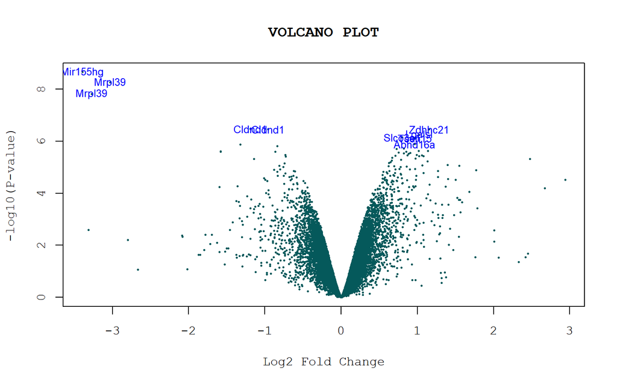

```r
volcanoplot(fit2, highlight = 10, names = fit2$genes$Symbol, main = "VOLCANO PLOT", family = "mono", col = "#05595B")
```

Aquí ya se puede visualizar las sondas con su nombre y en el eje de las X son los valores de Log2 Fold Change, y así poder ver si se diferencia; mientras más grande sea más diferencia. En el eje de las Y está el valor de *p*, en el que mientras más arriba estén, más valor significativo tiene.

## Generar tabla con los resultados

Dejar las sondas con criterios que queramos, en este caso será con un valor fold-change mayor a 1.5 y en el valor de *p* menor a 0.05

```r
deTable <- topTable(fit2, number=nrow(fit2), lfc=log2(1.5), p.value=0.05)

dim(deTable)
```

```
## [1] 219   8
```

```r
class(deTable)
```

```
## [1] "data.frame"
```

Tabla con todos los datos, ordenada por logFC.

```r
fullTable <- topTable(fit2, number=nrow(fit2), sort.by="logFC")

dim(fullTable)
```

```
## [1] 45101     8
```

# Guardar datos

No hay mucho que explicar aquí, solo guardar datos, jaja.

```r
write.table(fullTable, file="full_results.txt", row.names=FALSE, sep="\t", quote=FALSE)
```

# Preguntas

**¿Cuántas sondas predicen como diferencialmente expresadas?**

219 basándome en el punto de corte que se hizo para crear la tabla.

**¿Cuántos genes únicos hay en las listas?**

```r
unicos <- unique(fit2)

length(unicos)
```

```
## [1] 24
```